# finedi

```r
data_is_child <- read_csv("/Users/gb146/FineDi-Bergelson/fineDi/static/is_child.csv")
eng <- data_is_child %>% filter(lang=='english')
tsi <- data_is_child %>% filter(lang=='tsimane')

mean(data_is_child$length)
```

```
## [1] 1.133728
```

## Histogram of segment length by language

Due to Lena specs, clips are 600ms long or longer

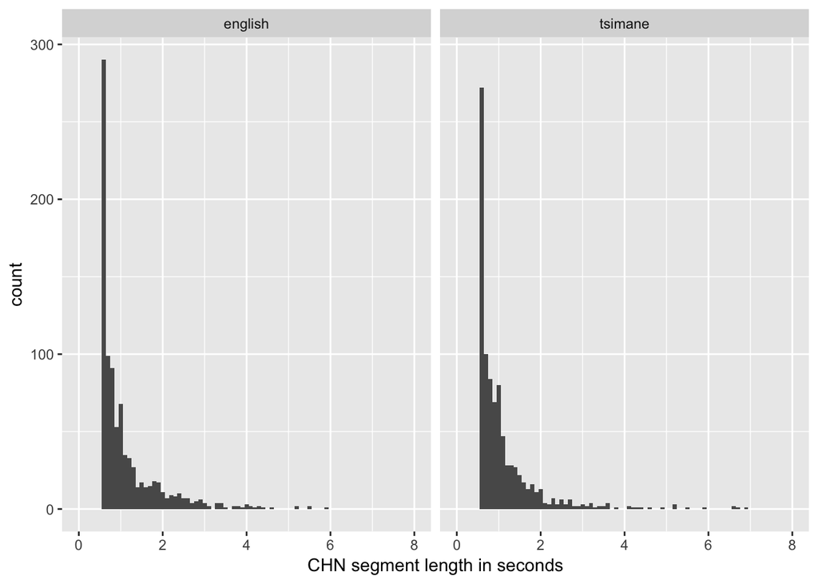

```r
ggplot(data=data_is_child, aes(data_is_child$length)) +
  geom_histogram(binwidth=0.1) + # binwidth to change
  xlim(0,8) +
  xlab("CHN segment length in seconds")+
  facet_wrap(~ lang)
```

## Percentage agreement

### Overall

This is computed over all segments that have been seen at least once. The #yes-agreement is the number of times a segment was labeled as key child as least once and never as not key child (reverse for #no-agreement). #agreement is the sum of the two. %yes-agreement is #yes-agreement divided by the number of segments labeled as key child by at least one person (reverse for %no-agreement). %agreement is #yes-agreement+#no-agreement divided by the total number of segments.

```
##          %Agreement  #Agreement  %Yes-agreement  #Yes-agreement
## Overall          59        1062              67             859
## English          63         570              72             462
## Tsimane          55         492              62             397
##          %No-agreement  #No-agreement
## Overall             39            203
## English             41            108
## Tsimane             37             95
```